# WageAnalysis

Nate Talampas

2025-08-07

# Connection to a MySQL Database

```r
# Libraries
library(RMariaDB)
library(DBI)
# parameters
user = 'root'
password = 'IlokanoAko1!'
database = 'db'
host = 'localhost'
port = 3306
```

```r
# connect to the database
connection = dbConnect(
  drv = MariaDB(),
  dbname = database,
  user = user,
  password = password,
  host = host,
  port = port
)
```

```r
# fetch results
data = tbl(connection, "ds_jobs") %>%
  collect()
```

```r
# Disconnect
dbDisconnect(connection)
```

```r
# extract columns of interest and store in df
df = data %>%
  dplyr::select(`Job Title`, `Rating`, `Company Name`, `Size`, `Founded`, `Type of ownership`, `Industry`, `Sector`, `Revenue`, `Competitors`, `min_salaryK`, `max_salaryK`, `avg_salaryK`, job_state, hq_state, same_state, machine_learning, python, sql, excel, hadoop, spark, aws, tableau, power_bi, big_data) %>%
  rename_with(~ str_replace_all(tolower(.), " ", "_")) %>%
   mutate(company_name = str_replace_all(company_name, "\\\\n|\n", "") %>%
                            str_trim())
head(df)
```

```
## # A tibble: 6 × 26
##   job_title  rating company_name size  founded type_of_ownership industry sector
##   <chr>       <dbl> <chr>        <chr> <int64> <chr>             <chr>    <chr>
## 1 Sr Data S…    3.1 Healthfirst  1001…    1993 Nonprofit Organi… Insuran… Insur…
## 2 Data Scie…    4.2 ManTech      5001…    1968 Company - Public  Researc… Busin…
## 3 Data Scie…    3.8 Analysis Gr… 1001…    1981 Private Practice… Consult… Busin…
## 4 Data Scie…    3.5 INFICON      501 …    2000 Company - Public  Electri… Manuf…
## 5 Data Scie…    2.9 Affinity So… 51 t…    1998 Company - Private Adverti… Busin…
## 6 Data Scie…    4.2 HG Insights  51 t…    2010 Company - Private Compute… Infor…
## # ℹ 18 more variables: revenue <chr>, competitors <chr>, min_salaryk <int>,
## #   max_salaryk <int>, avg_salaryk <int>, job_state <chr>, hq_state <chr>,
## #   same_state <int>, machine_learning <int>, python <int>, sql <int>,
## #   excel <int>, hadoop <int>, spark <int>, aws <int>, tableau <int>,
## #   power_bi <int>, big_data <int>
```

# Exploratory Data Analysis

```r
colSums(is.na(df))
```

```
##         job_title            rating      company_name              size
##                 0                39                 0                33
##           founded type_of_ownership          industry            sector
##               107                20                60                60
##           revenue       competitors       min_salaryk       max_salaryk
##               228               488                 0                 0
##       avg_salaryk         job_state          hq_state        same_state
##                 0                 0                 0                 0
##  machine_learning            python               sql             excel
##                 0                 0                 0                 0
##            hadoop             spark               aws           tableau
##                 0                 0                 0                 0
##          power_bi          big_data
##                 0                 0
```

- `rating` is missing 39 values
- `size` is missing 33 values
- `founded` is missing 107 values
- `type of ownership` is missing 20 values
- `industry` is missing 60
- `sector` is missing 60
- `revenue` is missing 228
- `competitors` is missing 488

Maybe sensitive company information like revenue and competitors are left off job applications.

```r
library(dplyr)
# Convert job_title column encoding to Latin1
df$job_title <- iconv(df$job_title, from = "", to = "latin1", sub = "")

df %>%
  count(job_title, sort = TRUE)
```

```
## # A tibble: 172 × 2
##    job_title                                                                   n
##    <chr>                                                                   <int>
##  1 Data Scientist                                                            326
##  2 Data Engineer                                                              26
##  3 Senior Data Scientist                                                      19
##  4 Machine Learning Engineer                                                  15
##  5 Data Analyst                                                               12
##  6 Senior Data Analyst                                                         6
##  7 Data Science Software Engineer                                              4
##  8 Data Scientist - TS/SCI FSP or CI Required                                  4
##  9 ENGINEER - COMPUTER SCIENTIST - RESEARCH COMPUTER SCIENTIST - SIGNAL P…     4
## 10 Senior Data Engineer                                                        4
## # ℹ 162 more rows
```

We can observe that Data Scientist is the number one job title on the job market in this dataset. It’s followed by Data Engineer, ML engineer, and Data Analyst. Other positions require Data Science skills, but the responsibilities are ambiguous to each company.

**Question of Interest: What skills can be grouped into components for analysis? This can be done with dimensionality reduction.**

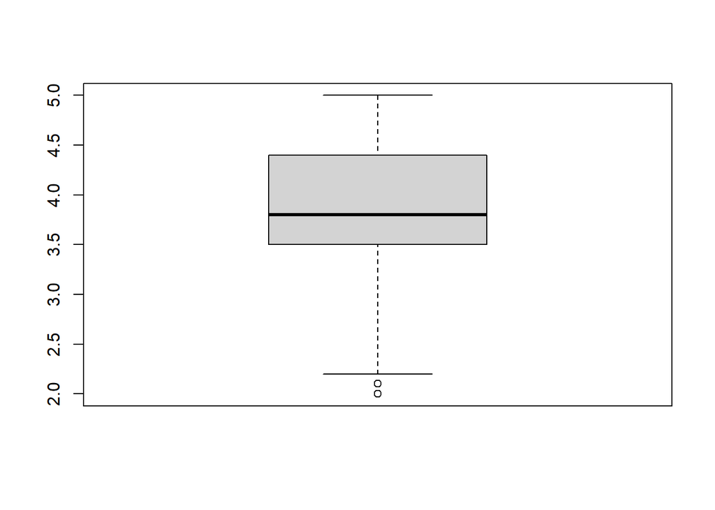

```r
boxplot(df$rating)
```

```r
summary(df$rating)
```

```
##    Min. 1st Qu.  Median    Mean 3rd Qu.    Max.    NA's
##   2.000   3.500   3.800   3.881   4.400   5.000      39
```

```r
df %>%
  count(size, sort = TRUE)
```

```
## # A tibble: 8 × 2
##   size                        n
##   <chr>                   <int>
## 1 51 to 200 employees       134
## 2 1001 to 5000 employees    104
## 3 1 to 50 employees          86
## 4 201 to 500 employees       84
## 5 10000+ employees           80
## 6 501 to 1000 employees      77
## 7 5001 to 10000 employees    61
## 8 <NA>                       33
```

Most of the companies have 51-200 or 1001-5000 employees. Do larger companies offer higher mean salaries?

We can feature engineer a company_size factor variable: small (1-200 employees), medium (201-1000), large (1001-10000+ employees)

```r
df <- df %>%
  mutate(
    company_size = case_when(
      size %in% c("1 to 50 employees", "51 to 200 employees") ~ "small",
      size %in% c("201 to 500 employees", "501 to 1000 employees") ~ "medium",
      size %in% c("1001 to 5000 employees", "5001 to 10000 employees", "10000+ employees") ~ "large",
      TRUE ~ NA_character_
    ),
    company_size = factor(company_size, levels = c("small", "medium", "large"))
  )

df %>% count(company_size, sort=T)
```

```
## # A tibble: 4 × 2
##   company_size     n
##   <fct>        <int>
## 1 large          245
## 2 small          220
## 3 medium         161
## 4 <NA>            33
```

```r
library(bit64)
```

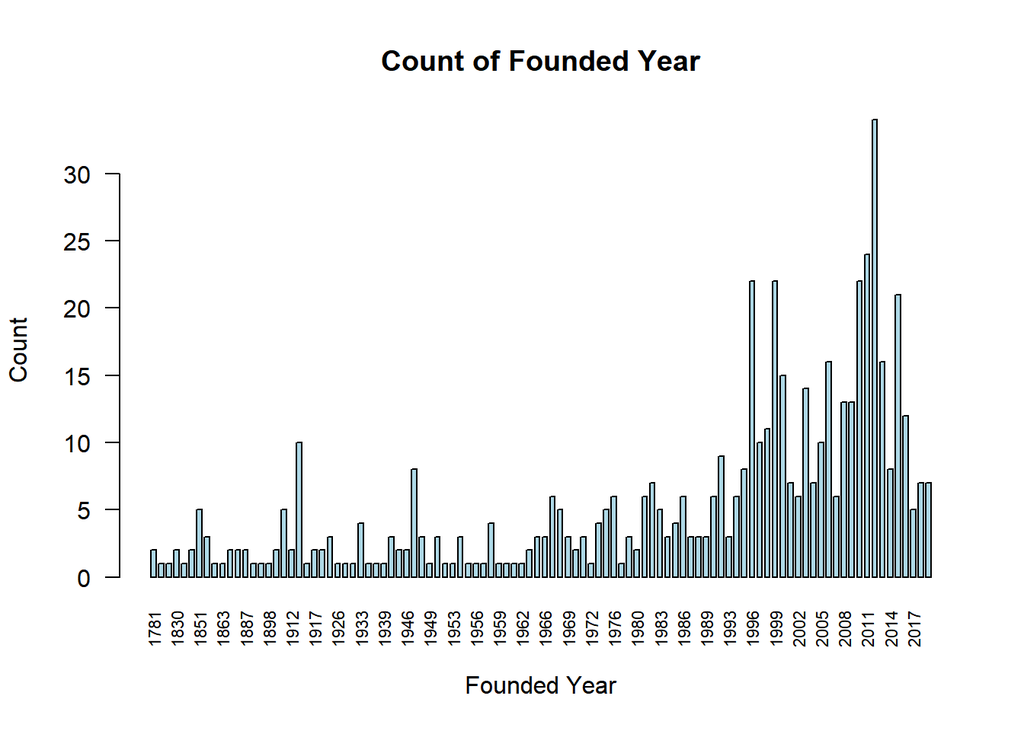

```r
df$founded_num <- as.numeric(df$founded)

# Create a frequency table of founded years
year_counts <- table(df$founded_num)

# Bar plot of counts per year
barplot(year_counts,
        las = 2,                  # Rotate labels for readability
        col = "lightblue",
        main = "Count of Founded Year",
        xlab = "Founded Year",
        ylab = "Count",
        cex.names = 0.7,          # Adjust label size
        space = 0.5)
```

Most of the companies were launched in the 2000s. This could be attributed to the rise of tech start ups. Do older companies pay more?

```r
df %>%
  count(type_of_ownership, sort = TRUE)
```

```
## # A tibble: 12 × 2
##    type_of_ownership                  n
##    <chr>                          <int>
##  1 Company - Private                395
##  2 Company - Public                 153
##  3 Nonprofit Organization            36
##  4 Subsidiary or Business Segment    28
##  5 <NA>                              20
##  6 Government                        10
##  7 Other Organization                 5
##  8 Private Practice / Firm            4
##  9 College / University               3
## 10 Contract                           2
## 11 Self-employed                      2
## 12 Hospital                           1
```

Most of the companies are in the private sector, followed by the public sector. Does private vs public have a pay difference?

```r
df <- df %>%
  mutate(
    ownership_type = case_when(
      type_of_ownership %in% c("Company - Private",
                                 "Company - Public") ~ type_of_ownership,
      TRUE ~ "Other"
    ),
    ownership_type = factor(ownership_type)
  )

df %>% count(ownership_type)
```

```
## # A tibble: 3 × 2
##   ownership_type        n
##   <fct>             <int>
## 1 Company - Private   395
## 2 Company - Public    153
## 3 Other               111
```

```r
df %>%
  count(sector, sort = TRUE)
```

```
## # A tibble: 23 × 2
##    sector                        n
##    <chr>                     <int>
##  1 Information Technology      187
##  2 Business Services           120
##  3 Biotech & Pharmaceuticals    66
##  4 <NA>                         60
##  5 Aerospace & Defense          46
##  6 Finance                      32
##  7 Insurance                    32
##  8 Manufacturing                23
##  9 Health Care                  21
## 10 Government                   17
## # ℹ 13 more rows
```

IT and Business Services are the top sectors. Do certain sectors pay more?

```r
df %>%
  count(revenue, sort = TRUE)
```

```
## # A tibble: 13 × 2
##    revenue                              n
##    <chr>                            <int>
##  1 <NA>                               228
##  2 $100 to $500 million (USD)          94
##  3 $10+ billion (USD)                  63
##  4 $2 to $5 billion (USD)              45
##  5 $10 to $25 million (USD)            41
##  6 $1 to $2 billion (USD)              36
##  7 $25 to $50 million (USD)            36
##  8 $1 to $5 million (USD)              31
##  9 $50 to $100 million (USD)           30
## 10 $500 million to $1 billion (USD)    19
## 11 $5 to $10 million (USD)             14
## 12 Less than $1 million (USD)          14
## 13 $5 to $10 billion (USD)              8
```

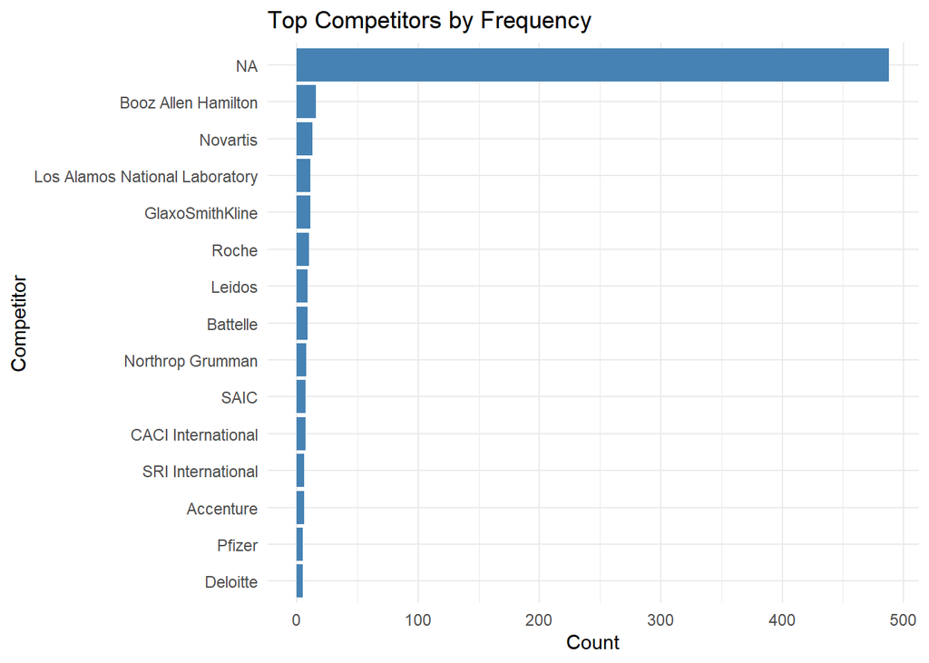

```r
# Split and unnest competitors into long format
competitors_long <- df %>%
  dplyr::select(competitors) %>%
  mutate(competitors = strsplit(as.character(competitors), ",")) %>%
  unnest(competitors) %>%
  mutate(competitors = trimws(competitors))  # Remove leading/trailing whitespace

competitor_counts <- competitors_long %>%
  group_by(competitors) %>%
  summarise(count = n()) %>%
  arrange(desc(count))

top_n <- 15
top_competitors <- competitor_counts %>%
  slice_head(n = top_n)

ggplot(top_competitors, aes(x = reorder(competitors, count), y = count)) +
  geom_col(fill = "steelblue") +
  coord_flip() +
  labs(title = "Top Competitors by Frequency",
       x = "Competitor",
       y = "Count") +
  theme_minimal()
```

Most job postings leave out their competitors, but the top reported competitors are Booz Allen Hamilton, Novartis, Los Alamos National Laboratory, GlaxoSmithKline, and Roche. Are these competitors in industries that are in high competition?

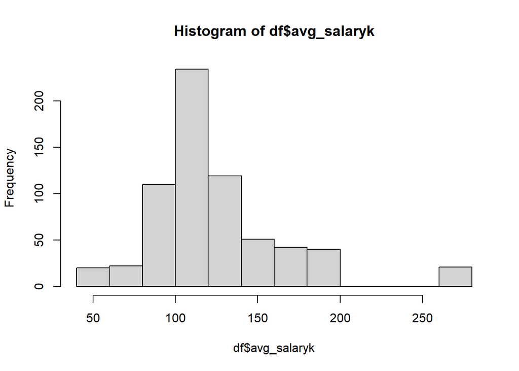

```r
hist(df$avg_salaryk)
```

```r
summary(df$avg_salaryk)
```

```
##    Min. 1st Qu.  Median    Mean 3rd Qu.    Max.
##      44     103     114     124     137     272
```

There seems to be outliers in average salary, since average salary is centered around $124,000. However, a fraction of the job postings have average salaries of above $250,000. This is an issue because these outliers may distort our regression coefficients. We can use Cook’s distance to identify outliers.

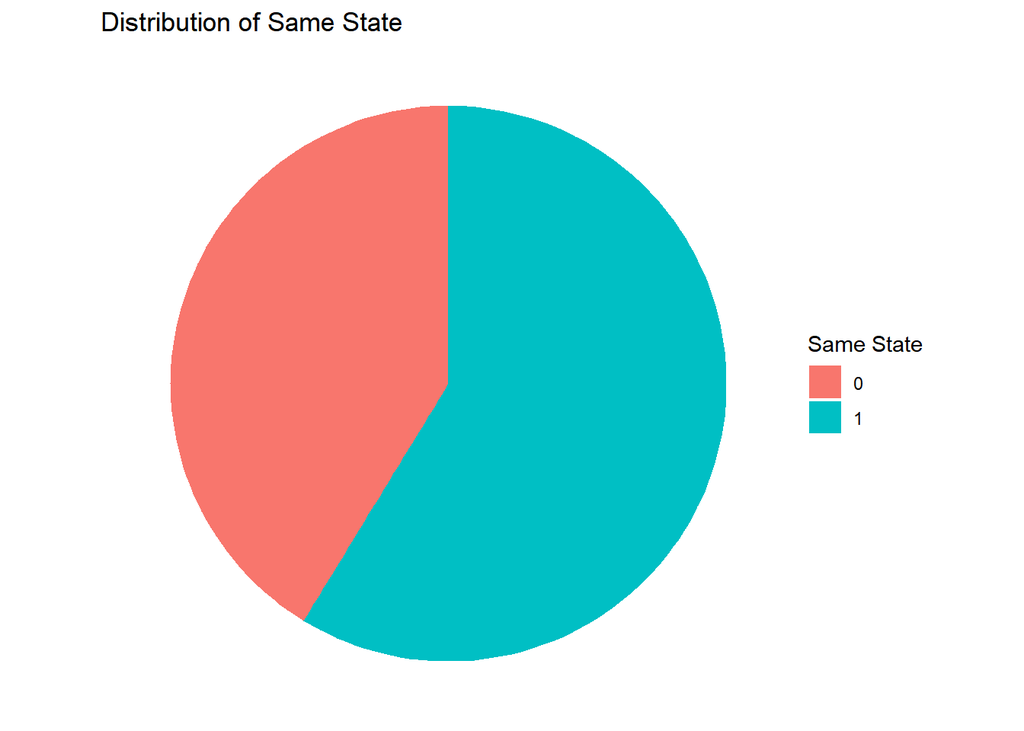

```r
# Create pie chart with ggplot2
ggplot(df, aes(x = "", fill = factor(same_state))) +
  geom_bar(width = 1) +
  coord_polar("y", start = 0) +
  labs(title = "Distribution of Same State",
       fill = "Same State") +
  theme_void()
```

The majority of job postings have their headquarters in the same state as the job’s station.

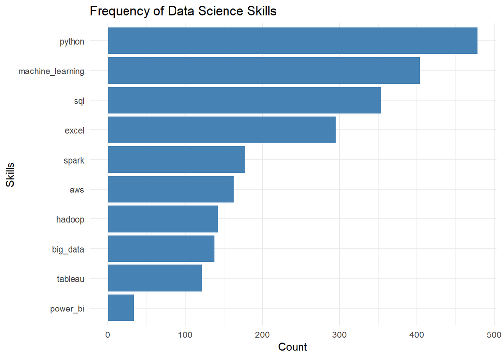

```r
library(ggplot2)
library(tidyr)
library(dplyr)

# Reshape data for ggplot
skills_long <- df %>%
  dplyr::select(machine_learning, python, sql, excel, hadoop,
         spark, aws, tableau, power_bi, big_data) %>%
  pivot_longer(everything(), names_to = "skill", values_to = "has_skill") %>%
  group_by(skill) %>%
  summarise(count = sum(has_skill, na.rm = TRUE))


# Create bar plot
ggplot(skills_long, aes(x = reorder(skill, count), y = count)) +
  geom_bar(stat = "identity", fill = "steelblue") +
  coord_flip() +  # Horizontal bars for better readability
  labs(title = "Frequency of Data Science Skills",
       x = "Skills",
       y = "Count") +
  theme_minimal()
```

Python, machine learning, and SQL are the top frequently counted skills on job postings. Do these skills correspond to higher average salary?

## Discussing missing values

```r
colSums(is.na(df))
```

```
##         job_title            rating      company_name              size
##                 0                39                 0                33
##           founded type_of_ownership          industry            sector
##               107                20                60                60
##           revenue       competitors       min_salaryk       max_salaryk
##               228               488                 0                 0
##       avg_salaryk         job_state          hq_state        same_state
##                 0                 0                 0                 0
##  machine_learning            python               sql             excel
##                 0                 0                 0                 0
##            hadoop             spark               aws           tableau
##                 0                 0                 0                 0
##          power_bi          big_data      company_size       founded_num
##                 0                 0                33               107
##    ownership_type
##                 0
```

```r
dim(df)
```

```
## [1] 659  29
```

```r
# can omit job_title since they are all data science related jobs
# can we use EM algorithm to impute missing values for rating
# company name is like a unique key, let's omit
# size must be a factor
# founded?
# type_of_ownership must be a factor
# industry must be a factor
# can omit competitors since most of its missing, and they don't answer the research question
# avg_salary is our target variable
# job_state must be a factor
# same_state is an indicator variable
# machine_learning, python, sql, excel, hadoop, spark, aws, tableau, power_bi, big_data are all binary variables


# Load required libraries
library(dplyr)
library(VIM)  # for EM algorithm imputation
#library(mice) # alternative for missing value imputation

# ================================================================
# DATA PREPARATION
# ================================================================

# Remove irrelevant columns
df_clean <- df %>%
  dplyr::select(-job_title, -company_name, -size, -competitors, -founded, -hq_state, -founded_num)

# Convert categorical variables to factors
df_clean$company_size <- as.factor(df_clean$company_size)
df_clean$ownership_type <- as.factor(df_clean$ownership_type)
df_clean$industry <- as.factor(df_clean$industry)
df_clean$sector <- as.factor(df_clean$sector)
df_clean$job_state <- as.factor(df_clean$job_state)
```

```r
head(df_clean, 30)
```

```
## # A tibble: 30 × 22
##    rating type_of_ownership      industry sector revenue min_salaryk max_salaryk
##     <dbl> <chr>                  <fct>    <fct>  <chr>         <int>       <int>
##  1    3.1 Nonprofit Organization Insuran… Insur… <NA>            137         171
##  2    4.2 Company - Public       Researc… Busin… $1 to …         137         171
##  3    3.8 Private Practice / Fi… Consult… Busin… $100 t…         137         171
##  4    3.5 Company - Public       Electri… Manuf… $100 t…         137         171
##  5    2.9 Company - Private      Adverti… Busin… <NA>            137         171
##  6    4.2 Company - Private      Compute… Infor… <NA>            137         171
##  7    3.9 Company - Public       Biotech… Biote… $10+ b…         137         171
##  8    3.5 Company - Public       Consume… Retail $1 to …         137         171
##  9    4.4 Company - Public       Compute… Infor… $2 to …         137         171
## 10    3.6 Company - Private      Enterpr… Infor… <NA>            137         171
## # ℹ 20 more rows
## # ℹ 15 more variables: avg_salaryk <int>, job_state <fct>, same_state <int>,
## #   machine_learning <int>, python <int>, sql <int>, excel <int>, hadoop <int>,
## #   spark <int>, aws <int>, tableau <int>, power_bi <int>, big_data <int>,
## #   company_size <fct>, ownership_type <fct>
```

```r
# we need company_size and ownership_type to be numeric features... so let's create binary/indicator variables

# Binary variables for company_size
df_clean$size_small <- ifelse(df_clean$company_size == "small", 1, 0)
df_clean$size_medium <- ifelse(df_clean$company_size == "medium", 1, 0)
df_clean$size_large <- ifelse(df_clean$company_size == "large", 1, 0)


# Binary variables for ownership_type
df_clean$own_private <- ifelse(df_clean$ownership_type == "Company - Private", 1, 0)
df_clean$own_public <- ifelse(df_clean$ownership_type == "Company - Public", 1, 0)
df_clean$own_other <- ifelse(df_clean$ownership_type == "Other", 1, 0)
```

```r
colSums(is.na(df_clean))
```

```
##            rating type_of_ownership          industry            sector
##                39                20                60                60
##           revenue       min_salaryk       max_salaryk       avg_salaryk
##               228                 0                 0                 0
##         job_state        same_state  machine_learning            python
##                 0                 0                 0                 0
##               sql             excel            hadoop             spark
##                 0                 0                 0                 0
##               aws           tableau          power_bi          big_data
##                 0                 0                 0                 0
##      company_size    ownership_type        size_small       size_medium
##                33                 0                33                33
##        size_large       own_private        own_public         own_other
##                33                 0                 0                 0
```

```r
# ================================================================
# mice FOR MULTIPLE IMPUTATION
# ================================================================

library(mice)
# Select only numeric predictors and a few relevant factors (exclude high-cardinality columns)
impute_data <- df_clean[, c("rating", "avg_salaryk", "min_salaryk", "max_salaryk")]

# Perform multiple imputation
imputed <- mice(impute_data, m = 1, method = "pmm", seed = 123)
# Replace the original rating column with imputed one
df_clean$rating <- complete(imputed)$rating
```

```r
colSums(is.na(df_clean))
```

```
##            rating type_of_ownership          industry            sector
##                 0                20                60                60
##           revenue       min_salaryk       max_salaryk       avg_salaryk
##               228                 0                 0                 0
##         job_state        same_state  machine_learning            python
##                 0                 0                 0                 0
##               sql             excel            hadoop             spark
##                 0                 0                 0                 0
##               aws           tableau          power_bi          big_data
##                 0                 0                 0                 0
##      company_size    ownership_type        size_small       size_medium
##                33                 0                33                33
##        size_large       own_private        own_public         own_other
##                33                 0                 0                 0
```

```r
summary(df_clean)
```

```
##      rating     type_of_ownership
##  Min.   :2.00   Length:659
##  1st Qu.:3.50   Class :character
##  Median :3.80   Mode  :character
##  Mean   :3.88
##  3rd Qu.:4.40
##  Max.   :5.00
##
##                                     industry                         sector
##  Biotech & Pharmaceuticals              : 66   Information Technology   :187
##  IT Services                            : 61   Business Services        :120
##  Computer Hardware & Software           : 56   Biotech & Pharmaceuticals: 66
##  Aerospace & Defense                    : 46   Aerospace & Defense      : 46
##  Enterprise Software & Network Solutions: 43   Finance                  : 32
##  (Other)                                :327   (Other)                  :148
##  NA's                                   : 60   NA's                     : 60
##    revenue           min_salaryk      max_salaryk     avg_salaryk
##  Length:659         Min.   : 31.00   Min.   : 56.0   Min.   : 44
##  Class :character   1st Qu.: 79.00   1st Qu.:119.0   1st Qu.:103
##  Mode  :character   Median : 91.00   Median :133.0   Median :114
##                     Mean   : 99.07   Mean   :148.5   Mean   :124
##                     3rd Qu.:122.00   3rd Qu.:165.0   3rd Qu.:137
##                     Max.   :212.00   Max.   :331.0   Max.   :272
##
##    job_state     same_state     machine_learning     python
##   CA    :154   Min.   :0.0000   Min.   :0.0000   Min.   :0.0000
##   VA    : 89   1st Qu.:0.0000   1st Qu.:0.0000   1st Qu.:0.0000
##   MA    : 62   Median :1.0000   Median :1.0000   Median :1.0000
##   NY    : 52   Mean   :0.5873   Mean   :0.6131   Mean   :0.7269
##   MD    : 40   3rd Qu.:1.0000   3rd Qu.:1.0000   3rd Qu.:1.0000
##   IL    : 30   Max.   :1.0000   Max.   :1.0000   Max.   :1.0000
##  (Other):232
##       sql             excel            hadoop           spark
##  Min.   :0.0000   Min.   :0.0000   Min.   :0.0000   Min.   :0.0000
##  1st Qu.:0.0000   1st Qu.:0.0000   1st Qu.:0.0000   1st Qu.:0.0000
##  Median :1.0000   Median :0.0000   Median :0.0000   Median :0.0000
##  Mean   :0.5372   Mean   :0.4476   Mean   :0.2155   Mean   :0.2686
##  3rd Qu.:1.0000   3rd Qu.:1.0000   3rd Qu.:0.0000   3rd Qu.:1.0000
##  Max.   :1.0000   Max.   :1.0000   Max.   :1.0000   Max.   :1.0000
##
```

[output cut: 9 more lines]

```
##  small :220   Company - Private:395    Min.   :0.0000   Min.   :0.0000
##  medium:161   Company - Public :153    1st Qu.:0.0000   1st Qu.:0.0000
##  large :245   Other            :111    Median :0.0000   Median :0.0000
##  NA's  : 33                            Mean   :0.3514   Mean   :0.2572
##                                        3rd Qu.:1.0000   3rd Qu.:1.0000
##                                        Max.   :1.0000   Max.   :1.0000
##                                        NA's   :33       NA's   :33
##    size_large      own_private       own_public       own_other
##  Min.   :0.0000   Min.   :0.0000   Min.   :0.0000   Min.   :0.0000
##  1st Qu.:0.0000   1st Qu.:0.0000   1st Qu.:0.0000   1st Qu.:0.0000
##  Median :0.0000   Median :1.0000   Median :0.0000   Median :0.0000
##  Mean   :0.3914   Mean   :0.5994   Mean   :0.2322   Mean   :0.1684
##  3rd Qu.:1.0000   3rd Qu.:1.0000   3rd Qu.:0.0000   3rd Qu.:0.0000
##  Max.   :1.0000   Max.   :1.0000   Max.   :1.0000   Max.   :1.0000
##  NA's   :33
```

```r
summary(df_clean$rating)
```

```
##    Min. 1st Qu.  Median    Mean 3rd Qu.    Max.
##    2.00    3.50    3.80    3.88    4.40    5.00
```

```r
summary(df$rating)
```

```
##    Min. 1st Qu.  Median    Mean 3rd Qu.    Max.    NA's
##   2.000   3.500   3.800   3.881   4.400   5.000      39
```

```r
# The distribution of rating did not change too much after imputing
```

## EDA on cleaned data

```r
head(df_clean)
```

```
## # A tibble: 6 × 28
##   rating type_of_ownership       industry sector revenue min_salaryk max_salaryk
##    <dbl> <chr>                   <fct>    <fct>  <chr>         <int>       <int>
## 1    3.1 Nonprofit Organization  Insuran… Insur… <NA>            137         171
## 2    4.2 Company - Public        Researc… Busin… $1 to …         137         171
## 3    3.8 Private Practice / Firm Consult… Busin… $100 t…         137         171
## 4    3.5 Company - Public        Electri… Manuf… $100 t…         137         171
## 5    2.9 Company - Private       Adverti… Busin… <NA>            137         171
## 6    4.2 Company - Private       Compute… Infor… <NA>            137         171
## # ℹ 21 more variables: avg_salaryk <int>, job_state <fct>, same_state <int>,
## #   machine_learning <int>, python <int>, sql <int>, excel <int>, hadoop <int>,
## #   spark <int>, aws <int>, tableau <int>, power_bi <int>, big_data <int>,
## #   company_size <fct>, ownership_type <fct>, size_small <dbl>,
## #   size_medium <dbl>, size_large <dbl>, own_private <dbl>, own_public <dbl>,
## #   own_other <dbl>
```

```r
df_filtered = df_clean %>%
  dplyr::select(rating, min_salaryk, max_salaryk, avg_salaryk, job_state, same_state, machine_learning, python, sql, excel, hadoop, spark, aws, tableau, power_bi, big_data, size_small, size_medium, size_large, own_private, own_public, own_other)
```

```r
library(corrplot)
X = dplyr::select(df_filtered, -c(avg_salaryk, min_salaryk, max_salaryk))
#y = df_clean$avg_salaryk

numeric_features <- names(dplyr::select(X, where(is.numeric)))
print(numeric_features)
```

```
##  [1] "rating"           "same_state"       "machine_learning" "python"
##  [5] "sql"              "excel"            "hadoop"           "spark"
##  [9] "aws"              "tableau"          "power_bi"         "big_data"
## [13] "size_small"       "size_medium"      "size_large"       "own_private"
## [17] "own_public"       "own_other"
```

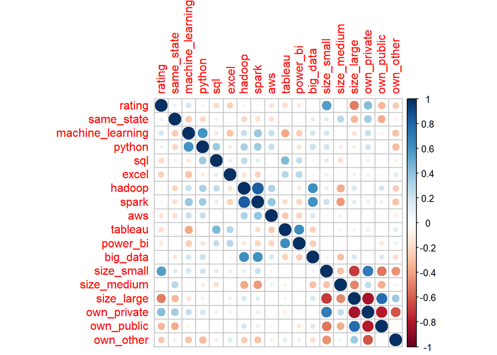

```r
X_numeric = dplyr::select(X, where(is.numeric))
corr_matrix = cor(X_numeric, use="pairwise.complete.obs")

cor.table = cor(corr_matrix)
corrplot(cor.table)
```

# PCA

```r
#colSums(is.na(df_filtered))

# only 33 rows are missing data out of 659... we can just drop
df_filtered <- na.omit(df_filtered)

X = dplyr::select(df_filtered, -c(avg_salaryk, min_salaryk, max_salaryk))
numeric_features <- names(dplyr::select(X, where(is.numeric)))
X_numeric = dplyr::select(X, where(is.numeric))
```

```r
pca_result = prcomp(X_numeric, center=T, scale.=T)
summary(pca_result)
```

```
## Importance of components:
##                           PC1    PC2     PC3    PC4     PC5     PC6     PC7
## Standard deviation     1.6880 1.5680 1.32130 1.2067 1.08965 1.03885 0.99754
## Proportion of Variance 0.1583 0.1366 0.09699 0.0809 0.06596 0.05996 0.05528
## Cumulative Proportion  0.1583 0.2949 0.39187 0.4728 0.53874 0.59869 0.65398
##                            PC8     PC9    PC10    PC11    PC12    PC13    PC14
## Standard deviation     0.97141 0.94416 0.92288 0.92009 0.81269 0.79628 0.74182
## Proportion of Variance 0.05242 0.04952 0.04732 0.04703 0.03669 0.03523 0.03057
## Cumulative Proportion  0.70640 0.75592 0.80324 0.85027 0.88697 0.92219 0.95276
##                           PC15    PC16      PC17      PC18
## Standard deviation     0.67559 0.62757 9.578e-16 3.452e-16
## Proportion of Variance 0.02536 0.02188 0.000e+00 0.000e+00
## Cumulative Proportion  0.97812 1.00000 1.000e+00 1.000e+00
```

```r
# PCA loadings (contribution of variables to each PC)
loadings <- pca_result$rotation

PC1 = loadings[, 1]
PC1[names(sort(abs(PC1), decreasing = TRUE))]
```

```
##      own_private       size_large       size_small       own_public
##       0.51578370      -0.46791076       0.40110355      -0.38699244
##           rating        own_other machine_learning           python
##       0.24772193      -0.24497750       0.14765939       0.13560835
##       same_state            spark      size_medium           hadoop
##       0.11330659       0.10686746       0.08436102       0.06187817
##              sql              aws         big_data            excel
##       0.05189629       0.04259620       0.04180289      -0.02825520
##          tableau         power_bi
##      -0.01827922       0.01463163
```

Private companies seem to be smaller.

```r
PC2 = loadings[, 2]
PC2[names(sort(abs(PC2), decreasing=T))]
```

```
##            spark           hadoop         big_data           python
##     -0.470762940     -0.458833753     -0.344513217     -0.303315816
##      size_medium machine_learning       own_public              aws
##      0.295508578     -0.217472358     -0.216208828     -0.206072469
##       size_large              sql        own_other       same_state
##     -0.206049523     -0.194214630      0.172550164      0.117429258
##      own_private       size_small          tableau         power_bi
##      0.064526564     -0.059901341     -0.041411681      0.008359935
##            excel           rating
##     -0.005943479     -0.004629038
```

Big data tools like spark and hadoop and python are grouped together.

```r
PC3 = loadings[, 3]
PC3[names(sort(abs(PC3), decreasing=T))]
```

```
##          tableau         power_bi              sql            excel
##      0.576086132      0.488929283      0.419515657      0.339314915
## machine_learning       same_state        own_other       own_public
##     -0.228969434      0.148623554      0.129924618     -0.128873597
##           rating           python           hadoop              aws
##     -0.115397735      0.072996266      0.057742369     -0.048037744
##         big_data            spark      size_medium       size_small
##     -0.047883766     -0.038380641     -0.031358570      0.022615975
##      own_private       size_large
##      0.018893343      0.005960423
```

Data visualization tools like tableau, power bi, sql are grouped together

```r
PC4 = loadings[, 4]
PC4[names(sort(abs(PC4), decreasing=T))]
```

```
##      size_medium       size_small              aws           python
##      0.628405552     -0.470548607      0.387885285      0.267517195
## machine_learning           rating       own_public       size_large
##      0.256218238     -0.208855867     -0.103975761     -0.102481949
##        own_other              sql            excel           hadoop
##      0.090930000      0.073948848      0.071612743      0.063033215
##       same_state          tableau            spark         big_data
##      0.059215012     -0.048505461      0.031598585      0.027230554
##      own_private         power_bi
##      0.025285180      0.003343585
```

medium sized companies like aws

```r
PC5 = loadings[, 5]
PC5[names(sort(abs(PC5), decreasing=T))]
```

```
##       same_state        own_other         big_data           python
##      0.451561403      0.423663892      0.369936238     -0.321856492
##       own_public            spark machine_learning           hadoop
##     -0.287593431      0.286401773     -0.285855284      0.258003469
##         power_bi              sql           rating          tableau
##     -0.127459469     -0.123530158      0.115914186     -0.095300385
##       size_small      own_private      size_medium       size_large
##     -0.060252896     -0.054489992      0.044039209      0.019499861
##              aws            excel
##      0.013974453     -0.001834032
```

jobs with companies in the same state seem to not be privately or publicly owned, and they want big data skills (might not be true)

```r
PC6 = loadings[, 6]
PC6[names(sort(abs(PC6), decreasing=T))]
```

```
##        own_other       own_public machine_learning           python
##       0.65380994      -0.36420863       0.34212354       0.32335915
##      size_medium       same_state       size_small      own_private
##      -0.23206276      -0.20017991       0.18539155      -0.15377360
##              sql           hadoop         power_bi         big_data
##       0.12625943      -0.12453126      -0.11172445      -0.09441869
##          tableau              aws            excel            spark
##      -0.07208799      -0.05383047      -0.04904945      -0.04423175
##       size_large           rating
##       0.02647523      -0.01814278
```

```r
PC7 = loadings[, 7]
PC7[names(sort(abs(PC7), decreasing=T))]
```

```
##           rating              aws machine_learning       same_state
##      0.510696973     -0.471276063      0.347301892      0.254632385
##         power_bi           python          tableau              sql
##      0.239405463      0.217375375      0.212116150     -0.199503036
##       size_small            excel      size_medium       own_public
##     -0.196057073     -0.185559953      0.146558317      0.130075319
##      own_private         big_data       size_large            spark
##     -0.124325760      0.106114372      0.060532022     -0.019683841
##        own_other           hadoop
##      0.014493088     -0.004569586
```

Job rating is positively associated with machine learning, same state and negatively related to aws.

```r
PC8 = loadings[, 8]
PC8[names(sort(abs(PC8), decreasing=T))]
```

```
##            excel              sql       same_state         big_data
##      0.724809190     -0.416388251     -0.254183421      0.234078635
##         power_bi machine_learning          tableau       own_public
##      0.216961899      0.198149621     -0.148688635     -0.128521620
##      own_private       size_large           python           hadoop
##      0.121138894      0.113489577     -0.104347970     -0.078450064
##      size_medium       size_small           rating              aws
##     -0.064367763     -0.057088877      0.051089889     -0.046141596
##        own_other            spark
##     -0.011965356      0.005139998
```

# Findings

For job seekers, these findings can provide a strategic edge in targeting opportunities that align with both career goals and preferred work environments. Knowing that private companies are often smaller may appeal to candidates seeking close-knit teams, faster decision-making, and broader role responsibilities, whereas those aiming for AWS-related roles might focus their search on medium-sized employers. Recognizing that certain skills cluster together — such as big data technologies (Spark, Hadoop, Python) or data visualization tools (Tableau, Power BI, SQL) — allows applicants to strengthen complementary skills that are likely to be requested together, increasing their competitiveness. Furthermore, understanding how job ratings relate to skill requirements can help prioritize applications: roles emphasizing machine learning or located within the same state may be linked to higher satisfaction, while heavy AWS emphasis could signal a more demanding technical environment. Overall, these insights help candidates tailor their skill development and job search strategy to maximize fit and potential satisfaction.